# Q1.1

# Q1.2

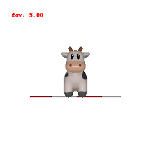

# Q2.1

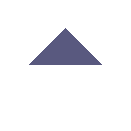

Number of vertices: 4  
Number of faces: 4

# Q2.2

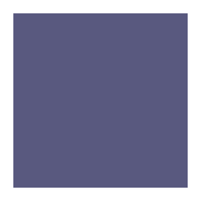

Number of vertices: 8  
Number of faces: 12

# Q3

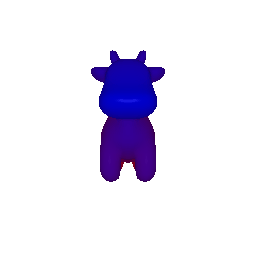

# Q4

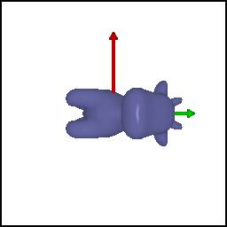

[figure not shown]

[figure not shown]

[figure not shown]

R_relative and T_relative are providing requuired transformations in the camera frame.

First Transformation:  
R_relative -> [[0, -1, 0], [1, 0, 0], [0, 0, 1]]  
T_relative -> [0,0,0]

Second Transformation:  
R_relative -> [[1, 0, 0], [0, 1, 0], [0, 0, 1]]  
T_relative -> [0,0,2]

Third Transformation:  
R_relative -> [[1, 0, 0], [0, 1, 0], [0, 0, 1]]  
T_relative -> [0.6, -0.5, 0]

Fourth Transformation:  
R_relative -> [[0, 0, -1], [0, 1, 0], [1, 0, 0]]  
T_relative -> [3, 0, 3]

# Q5.1

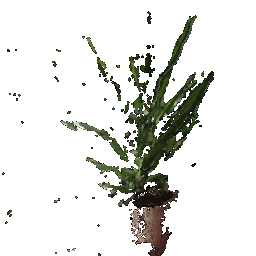

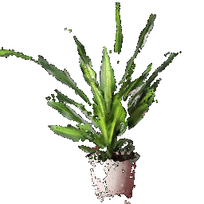

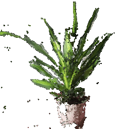

# Q5.2

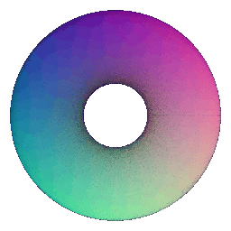

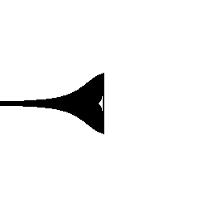

# Q5.3

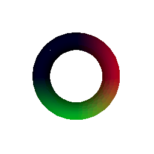

Trade-offs between rendering a mesh and pointcloud:

1. Rendering Speed: Mesh rendering involves more complex geometry and shading calculations. Rendering a detailed mesh with many vertices and faces can be computationally expensive. Point cloud rendering is comparatively faster
2. Rendering Quality: Higher render quality in mesh. The level of detail is not that dense with pointcloud
3. Memory consumption: Meshes with a large number of vertices and faces can consume significant memory, whereas, in pointcloud it can be kower as a point only requires storage for its 3D coordinates and potentially color information
4. Ease of use: Working with meshes may involve additional steps such as mesh creation, UV mapping, and ensuring the mesh is watertight. This process can be more complex than working with point clouds

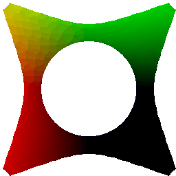

# Q6

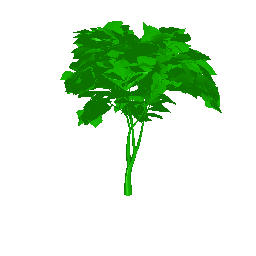

# Q7

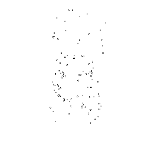

[figure not shown]

[figure not shown]